# Instalación hadoop ubuntu

## indicaciones

se va a instalar [ubuntu server](https://ubuntu.com/download/server) , se usara la version minima para crear la maquina base que va a contener java 1.8 , si tienen mas recursos en su maquina pueden usar la version normal .

La version minima funciona con 1024 de ram , 10gb de memoria , 1 o 2 nucleos. al instalar pueden usar el que te particiona el lvm por defecto o establecer cuanta memoria se requiere para cada elemento en el kernel de linux.

Para facilitar el uso de las configuraciones se sugiere emplear una misma clave , para todas las conexiones no perjudica mucho al ser esta instalación de uso práctico.

Tambien se puede habilitar una carpeta compartida entre el virtual box y la pc , esto podria ser util si el nat dentro de la maquina virtual no conecta a internet o para probar archivos jar en la maquina virtual.

[figure not shown]

[figure not shown]

```python
## instalamos nano
sudo apt install nano
## ssh
sudo apt install ssh
## instalamos ping
sudo apt install iputils-ping

## instalamos rsync
sudo apt-get install -y rsync
#comprobar
systemctl status ssh

## net tools
sudo apt-get install net-tools
## para instalar java

sudo apt-get update

sudo apt-get install openjdk-8-jdk

## comprobamos
javac -version
java -version
```

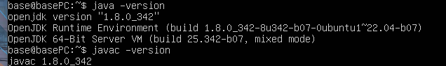

Esta maquina vendría a ser nuestra base para realizar las demás instalaciones clonariamos esta máquina .

[figure not shown]

dentro de la maquina que hemos clonado creamos un usuario donde instalaremos el hadoop y agregaremos a sudoers el usuario creado.

```python
## creamos el grupo hadoop para el usuario con hadoop
sudo addgroup hadoop
## creamos el usuario
sudo adduser --ingroup hadoop hduser
## agregamos a sudoers  el usuario creado
##sudo adduser <username> sudo
sudo adduser hduser sudo
## verificamos
## groups <username>
groups hduser

## para conectarnos
## sudo su - <username>
sudo su - hduser
```

Ahora generaremos una clave publica

```python
## para generar clave publica

sudo ssh-keygen -t rsa
## al generar clave nos sale la ruta donde esta esta clave
## al partir de esta tbn podremos mover la clave generada usando la ruta completa dentro del comando
## moveremos la clave
## emplear la ruta completa que aparece en el momento de generar la clave
##
sudo cat /root/.ssh/id_rsa.pub >> /root/.ssh/authorized_keys

## cambiamos permisos
## tbn podemos usar la ruta completa
sudo chmod 640 /root/.ssh/authorized_keys
## verificamos la conexion
## como se menciono anteriormente se sugiere emplear las mismas claves
## esto nos  facilita las conexiones
##comprobamos
ssh localhost
```

Dentro del usuario descargaremos hadoop

```python
## ultima version estable
wget https://downloads.apache.org/hadoop/common/stable/hadoop-3.3.4.tar.gz

## hadoop 2.8.4

wget https://archive.apache.org/dist/hadoop/common/hadoop-2.8.4/hadoop-2.8.4.tar.gz

## extraemos el archivo
# si es la estable
tar -xvzf hadoop-3.3.1.tar.gz
# si es  la version 2.8.4
tar -xvzf hadoop-2.8.4.tar.gz

## cambiamos y renombramos el directorio
sudo mv hadoop-2.8.4 /usr/local/hadoop

## creamos el directorio logs
sudo mkdir /usr/local/hadoop/logs
## asignamos la propiedad del directorio al usuario hduser
sudo chown hduser:hadoop -R /usr/local/hadoop
```

Configuramos las variables de entorno

```python
##para el simbolo ~ funciona con altgr + 4 si la distribucion del teclado es latina
sudo nano ~/.bashrc
#dentro del archivo agregamos lo siguiente

export HADOOP_HOME=/usr/local/hadoop
export HADOOP_INSTALL=$HADOOP_HOME
export HADOOP_MAPRED_HOME=$HADOOP_HOME
export HADOOP_COMMON_HOME=$HADOOP_HOME
export HADOOP_HDFS_HOME=$HADOOP_HOME
export YARN_HOME=$HADOOP_HOME
export HADOOP_COMMON_LIB_NATIVE_DIR=$HADOOP_HOME/lib/native
export PATH=$PATH:$HADOOP_HOME/sbin:$HADOOP_HOME/bin
export HADOOP_OPTS="-Djava.library.path=$HADOOP_HOME/lib/native"

## activamos las variables de entorno
source ~/.bashrc
```

```python
##ubicamos las rutas donde esta java
which java

## con la ruta
readlink -f /usr/bin/javac
```

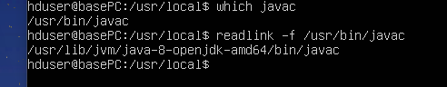

```python
## agregamos o configuramos  en el bashrc
export JAVA_HOME=/usr/lib/jvm/java-8-openjdk-amd64
export HADOOP_CLASSPATH+=" $HADOOP_HOME/lib/*.jar"
## agregar a /usr/local/hadoop/etc/haddop/hadoop-env.sh

export JAVA_HOME=/usr/lib/jvm/java-8-openjdk-amd64

## dentro de lib
cd /usr/local/hadoop/lib

## descargamos Javax
sudo wget https://jcenter.bintray.com/javax/activation/javax.activation-api/1.2.0/javax.activation-api-1.2.0.jar

## verificamos  la version de hadoop

hadoop version
```

configuramos core-site.xml

```python
sudo nano $HADOOP_HOME/etc/hadoop/core-site.xml

## dentro del archivo agregamos
<configuration>
   <property>
      <name>fs.default.name</name>
      <value>hdfs://0.0.0.0:9000</value>
      <description>The default file system URI</description>
   </property>
</configuration>
```

```python
## creamos los folder datanode,namenode

sudo mkdir -p /usr/local/hadoop_tmp/hdfs/{namenode,datanode}

#asignamos al usuario hduser como propietario
sudo chown hduser:hadoop -R /usr/local/hadoop_tmp
```

configuramos hdfs-site.xml

```python
<configuration>
   <property>
      <name>dfs.replication</name>
      <value>1</value>
   </property>

   <property>
      <name>dfs.name.dir</name>
      <value>file:///usr/local/hadoop_tmp/hdfs/namenode</value>
   </property>

   <property>
      <name>dfs.data.dir</name>
      <value>file:///usr/local/hadoop_tmp/hdfs/datanode</value>
   </property>
</configuration>
```

configuramos mapred-site.xml

```python
## si  se tiene el template  lo renombramos
## nos ubicamos el directorio

cd /usr/local/hadoop/etc/hadoop

# renombramos

mv mapred-site.xml.template mapred-site.xml

## configuramos el archivo
<configuration>
   <property>
      <name>mapreduce.framework.name</name>
      <value>yarn</value>
   </property>
</configuration>
```

configuramos yarn-site.xml

```python
# abrimos el archivo
sudo nano $HADOOP_HOME/etc/hadoop/yarn-site.xml

## configuramos

<configuration>
   <property>
      <name>yarn.nodemanager.aux-services</name>
      <value>mapreduce_shuffle</value>
   </property>
</configuration>
```

Esta es la parte final , al acitvar los servicios nos pide la clave que usamos al generar la llave publica con ssh, que seria en este caso la misma clave que hemos estado usando.

Si ocurre algun error dentro formateo y/o activar o desactivar los servicios la manera rapido de solucionar seria eliminando la carpeta hadoop_tmp y volvear a crear y otorgar los permisos al usuario hduser , tener en cuenta que si ocurre una mala activación puede que al intentar activar de nuevo ocurra una diferencia de IDs , al formatear se genera un ID que luego el core de hadoop usa para empezar y/o terminar los servicios , eliminar el folder donde esta el namenode , datanode nos soluciona este error de manera rapida

```python
##formateamos hdfs

hdfs namenode -format

## activamos los daemons
start-dfs.sh
start-yarn.sh
#comprobamos los servicios
jps

## para detener los servicios
stop-dfs.sh
stop-yarn.sh
```

## Instalación de hadoop multicluster

Se va a emplear un modelo maestro/esclavo , se va a emplear una red estatica ,se puede escoger cualquiera . Para esta se usara la 192.168.1.0 con mascara 255.255.255.0 , usaremos ips fijas dentro de esa red para cada elemento del modelo .

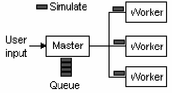

### Indicaciones

se va emplear dos esclavos , que van a ser copias de la maquina base , mientras que el maestro va a ser una copia de la maquina con hadoop de un solo nodo .

```python
##creamos el usuario hduser dentro de todas las maquinas si no estan creadas

sudo addgroup hadoop
## creamos el usuario
sudo adduser --ingroup hadoop hduser
## agregamos a sudoers  el usuario creado
##sudo adduser <username> sudo
sudo adduser hduser sudo
## verificamos
## groups <username>
groups hduser

## para conectarnos
## sudo su - <username>
sudo su - hduser
```

Asignamos la ip estatica en cada maquina .

```python
## configuramos el hostname en cada maquina

sudo hostname master
sudo hostname slave1
sudo hostname slave1
#para visualizar las interfaz en cada maquina
ifconfig

## ip en el master   192.168.1.14
## ip en el slave1   192.168.1.15
## ip en el slave2   192.168.1.16
## si la version de ubuntu contiene /etc/network/interfaces


sudo nano /etc/network/interfaces

auto eth0
iface eth0 inet static
  address 192.168.0.14
  netmask 255.255.255.0
  dns-nameservers 4.4.4.4
  dns-nameservers 8.8.8.8

## con netplan
## en netplan
cd /etc/netplan

## deberia de haber un archivo  yaml
## en el archivo  configuramos
## al modificar cuidar la identación
network:
  ethernets:
    enp0s3:
      dhcp4:  true
    enp0s8:
      dhcp4:  no
      addresses:  [192.168.1.14/24]
      nameservers:  {}
  version:2
## aplicamos los cambios

sudo netplan apply

## si presentamos errores

sudo netplan --debug apply


### agregar en /etc/hosts para cada elemento de la red
192.168.1.14 master
192.168.1.15 slave1
192.168.1.16 slave2
## de la misma manera en cada elemento del modelo
## comprobamos la conexion en la red estatica

ping master
ping slave1
ping slave2
```

Compartimos la clave publica generado con ssh en el hadoop single a los esclavos.

Como se menciono anteriormente al usar las mismas claves hace que estas conexiones sean mas sencillas.

```python
### MASTER

## localizamos el archivo
sudo find / -iname id_rsa.pub

## con la ruta

sudo ssh-copy-id -i /root/.ssh/id_rsa.pub hduser@slave1
sudo ssh-copy-id -i /root/.ssh/id_rsa.pub hduser@slave1

## comprobamos la conexión

ssh hduser@slave1
ssh hduser@slave1
## para cerrar la conexion
exit
```

En el maestro actualizaremos la configuración

```python
## direccion de los archivos
## /usr/local/hadoop/etc/hadoop

## core site
sudo nano $HADOOP_HOME/etc/hadoop/core-site.xml
## si estan el directorio
# sudo nano core-site.xml
## en el archivo agregamos y/o actualizamos
## master viene a ser la denominación al host maestro
<property>
  <name>fs.default.name</name>
  <value>hdfs://master:9000</value>v
</property>

## hdfs site
sudo nano $HADOOP_HOME/etc/hadoop/hdfs-site.xml

## agregamos y/o actualizamos
<property>
  <name>dfs.replication</name>
  <value>3</value>
</property>

## yarn site

sudo nano $HADOOP_HOME/etc/hadoop/yarn-site.xml
## agregamos y/o actualizamos
<property>
	<name>yarn.resourcemanager.resource-tracker.address</name>
	<value>master:8025</value>
</property>
<property>
	<name>yarn.resourcemanager.scheduler.address</name>
	<value>master:8035</value>
</property>
<property>
	<name>yarn.resourcemanager.address</name>
	<value>master:8050</value>
</property>

## mapred site

sudo nano $HADOOP_HOME/etc/hadoop/mapred-site.xml

## agregamos y/o actualizamos

<property>
	<name>mapreduce.job.tracker</name>
	<value>master:5431</value>
</property>
<property>
	<name>mapred.framework.name</name>
	<value>yarn</value>
</property>
##

sudo nano $HADOOP_HOME/etc/hadoop/masters

##

master

sudo nano $HADOOP_HOME/etc/hadoop/slaves

##
slave1
slave2
```

Ahora desde el maestro vamos a enviar la configuracion a cada esclavo dentro de la red. El maestro vendria a ser una copia del hadoop single que hemos actualizado , mientras los esclavos una copia del maquina base . Debido a que el directorio /usr/local es propiedad de root no podemos hacer rsync directamente. Crearemos un directorio temporal dentro de /usr/local donde enviaremos la configuración del hadoop desde el maestro. Despues en la maquina esclavo moveremos el directorio hadoop a /usr/local .

```python
## En el  esclavo

## creamos el directorio que va a recibir la información
cd /usr/local
sudo  mkdir hadoop_t

## Asignamos a nuestro usuario propiedad del directorio

sudo chown hduser:hadoop -R /usr/local/hadoop_t
## En el maestro
## clonamos la instalación de hadoop
sudo rsync -avxP /usr/local/hadoop hduser@slave1:/usr/local/hadoop_t/
## En el esclavo
#nos movemos al fichero
cd  /usr/local/hadoop_t
##  movemos el directorio hadoop
sudo mv hadoop /usr/local/hadoop
## eliminamos el directorio temporal
sudo rm -rf /usr/local/hadoop_t
```

```python
## EN EL MAESTRO

## eliminamos el directorio hadoop_tmp
## contiene los directorio namenode , datanode

sudo rm -rf /usr/local/hadoop_tmp

## creamos un nuevo directorio

sudo mkdir -p /usr/local/hadoop_tmp/
sudo mkdir -p /usr/local/hadoop_tmp/hdfs/namenode

## Asignamos a nuestro usuario como propietario

sudo chown hduser:hadoop -R /usr/local/hadoop_tmp/

## EN LOS ESCLAVOS

## eliminamos el directorio si esta creado
sudo rm -rf /usr/local/hadoop_tmp

## creamos un nuevo directorio

sudo mkdir -p /usr/local/hadoop_tmp/
sudo mkdir -p /usr/local/hadoop_tmp/hdfs/datanode

## Asignamos a nuestro usuario como propietario

sudo chown hduser:hadoop -R /usr/local/hadoop_tmp/
```

```python
## En el maestro
 hdfs namenode -format

 ##
 start-dfs.sh

 ##
 start-yarn.sh

 ##

 stop-dfs.sh

 ##

 stop-yarn.sh
```

```python
## verificar que al  conectarse en el usuario
## hduser
## el hostname este denominado como

## master --- en el maestro
## en los esclavos
## slave1
## slave2
## slave3
# de no ser asi actulizar el hostname

sudo hostname master
sudo hostname slave1
sudo hostname slave2
```

## Carpeta Compartida configuración

### indicaciones

Lo más optimo sería realizar esta parte en la maquina base para no tener que replicar toda la configuración .

Agregamos manualmente las guest additions

[figure not shown]

```python
sudo apt update
sudo apt install build-essential dkms linux-headers-$(uname -r)
sudo mkdir -p /mnt/cdrom
sudo mount /dev/cdrom /mnt/cdrom
cd /mnt/cdrom
sudo ./VBoxLinuxAdditions.run

## si no se completa
## verificar que paquete nos falta instalar pueden ser

sudo apt install gcc make perl
sudo /sbin/rcvboxadd quicksetup all

## cambiamos permisos en la carpeta compartida que debe de estar en /media/sf_<nombre_folder>

sudo chmod 777 /media/sf_<nombre_folder>

## ya debería de estar todo listo para usar
```